# Coursera project of course “Data Science Specialization: Practical Machine Learning”

Author: Armin Leichtfuss

# Executive Summary

In conformity with a trend to biometrical analyses we investiigated the way how people performed a secific fitness training. Using the recorded movement coordinates we tried to set up a model which is able to classify how well they did the exercise. The “Random Forest”-approach resulted in an extremely good prediction capability.

# Introduction

Using devices such as Jawbone Up, Nike FuelBand, and Fitbit it is now possible to collect a large amount of data about personal activity relatively inexpensively. These type of devices are part of the quantified self movement - a group of enthusiasts who take measurements about themselves regularly to improve their health, to find patterns in their behavior, or because they are tech geeks. One thing that people regularly do is quantify how much of a particular activity they do, but they rarely quantify how well they do it. In this project, your goal will be to use data from accelerometers on the belt, forearm, arm, and dumbell of 6 participants. They were asked to perform barbell lifts correctly and incorrectly in 5 different ways.

The goal of the project is to predict the manner in which they did the exercise. This is the “classe” variable in the training set. You may use any of the other variables to predict with. You should create a report describing how you built your model, how you used cross validation, what you think the expected out of sample error is, and why you made the choices you did. You will also use your prediction model to predict 20 different test cases.

# Data source, loading data

The data for this project come from this source: http://groupware.les.inf.puc-rio.br/har.

The training data for this project are available here:

https://d396qusza40orc.cloudfront.net/predmachlearn/pml-training.csv

The test data are available here:

https://d396qusza40orc.cloudfront.net/predmachlearn/pml-testing.csv

At first read contents of file [pml-training.csv] into data frame [df]. NA-values could be identified by taking a look into the file.

# Exploring and Tidying Data

The “classe”-variable shall be predicted! First of all we are interested what kind of values are in this variable?

```
## 'data.frame':    19622 obs. of  1 variable:
##  $ classe: Factor w/ 5 levels "A","B","C","D",..: 1 1 1 1 1 1 1 1 1 1 ...
```

```
##  classe
##  A:5580
##  B:3797
##  C:3422
##  D:3216
##  E:3607
```

For modeling purposes let us keep in mind that “classe” is a categorical variable.

Now, what are the dimensions of the data set, i.e. how many lines and columns?

There are 19622 lines and 160 columns in the data frame. The number of rows in the dataset is definitely sufficient for modeling in view of 5 different values in factor variable “classe”.

This means we have 159 candidates for predictor variables. In order to get a valuable and interpretable model we have to get rid of a significant number of variables.

In this assignment we are foremost concerned about the correct execution of the movement only, which means that we can leave out columns 1 to 7. If we would be interested in a statement like “Does user x perform better than user y?” or something like that we would do a simple correlation check. Of course, if we would want to predict “Will user z perform well?”, we need to consider variable “User”.

It is plain to see (using “head” or “str”) that a number of columns seem to be empty, so let´s get rid of columns which are less than 75% filled with values.

```r
removeCols <- which((colSums(is.na(df)) > 0.25*nrow(df)))
if (length(removeCols) > 0) {df <- df[,-removeCols]}
```

Next we make an attempt to identify so-to-speak “almost constant” variables by applying the “nearZeroVar”-function in the caret package.

```r
removeCols <- nearZeroVar(df)
if (length(removeCols) > 0) {df <- df[,-removeCols]}
```

The function identified 0 variables in this concern, and we will remove these columns from our data frame, too.

```r
usedCols <- colnames(df)   #keep the remaining columns in mind for the 20-record test data
```

By the way, this hasn´t been any pre-processing so far, just trying to get the complexity reduced by identifying a reasonable number of irrelevant columns. Therefore it can (or should) be executed on the whole data set (before splitting into train and test data).

Are there any NA-values left?

```r
NACols <- which((colSums(is.na(df)) > 0))
length(NACols)
```

```
## [1] 0
```

So we do not need to impute values (in pre-processing).

# Split data

Now we split the data into training and test set with a ratio of 6:4 like we´ve seen many times before.

```r
set.seed(16960)
idxTrain <- createDataPartition(y=df$classe, p=0.6, list=FALSE)
trainData <- df[idxTrain,]
testData <- df[-idxTrain,]
dim(trainData); dim(testData)
```

```
## [1] 11776    53
```

```
## [1] 7846   53
```

# Machine Learning - Identify Model

First of all we need to be aware of the type of model we can use for the assignment. Since “classe” is a categorical variable e.g. “standard” linear regression is out of question.

Compute accuracy (i.e. predicted values versus true values) of training(!) data:

```r
confusionMatrix(predict(modrpart, newdata=trainData), trainData$classe)
```

```
## Confusion Matrix and Statistics
##
##           Reference
## Prediction    A    B    C    D    E
##          A 3054  980  955  892  320
##          B   48  752   67  324  287
##          C  236  547 1032  714  560
##          D    0    0    0    0    0
##          E   10    0    0    0  998
##
## Overall Statistics
##
##                Accuracy : 0.4956
##                  95% CI : (0.4865, 0.5047)
##     No Information Rate : 0.2843
##     P-Value [Acc > NIR] : < 2.2e-16
##
##                   Kappa : 0.3402
##  Mcnemar's Test P-Value : NA
##
## Statistics by Class:
##
##                      Class: A Class: B Class: C Class: D Class: E
## Sensitivity            0.9122  0.32997  0.50243   0.0000  0.46097
## Specificity            0.6266  0.92355  0.78842   1.0000  0.99896
## Pos Pred Value         0.4925  0.50880  0.33409      NaN  0.99008
## Neg Pred Value         0.9473  0.85172  0.88235   0.8361  0.89162
## Prevalence             0.2843  0.19353  0.17442   0.1639  0.18385
## Detection Rate         0.2593  0.06386  0.08764   0.0000  0.08475
## Detection Prevalence   0.5266  0.12551  0.26231   0.0000  0.08560
## Balanced Accuracy      0.7694  0.62676  0.64543   0.5000  0.72996
```

The result of the decision tree is strange since there are no predictions for classe “D”. However, in the context of this project assignment I was not able to go into further investigations. We could e.g. explore the structure of the tree

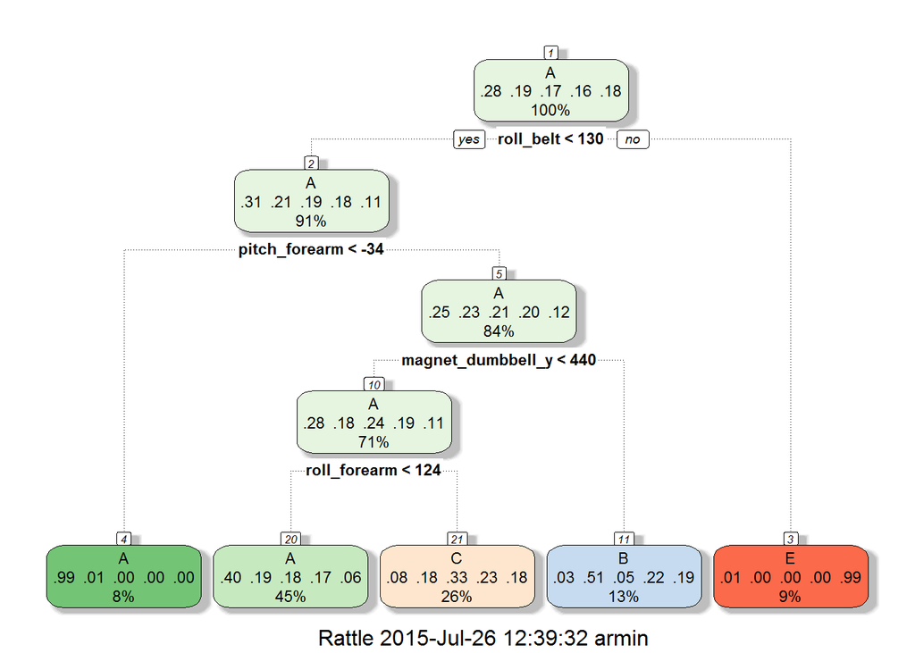

```r
#plot(modrpart$finalModel)
#text(modrpart$finalModel)
fancyRpartPlot(modrpart$finalModel)
```

or the relevance or impact of the variables

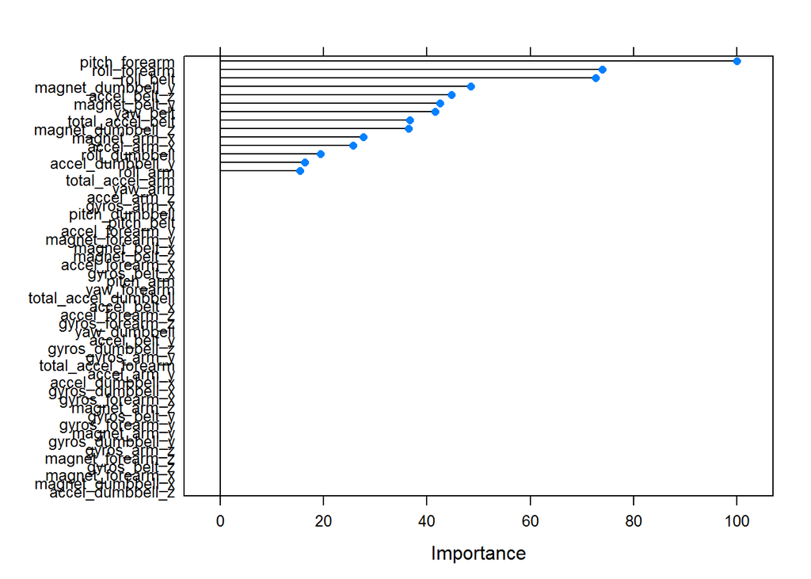

```r
plot(varImp(modrpart))
```

Check accuracy of the “Naive Bayes” model:

```r
confusionMatrix(predict(modnb, newdata=trainData), trainData$classe)
```

```
## Confusion Matrix and Statistics
##
##           Reference
## Prediction    A    B    C    D    E
##          A 2512  180  108  117   64
##          B  135 1611  140   10  209
##          C  311  332 1758  330  102
##          D  369  136   47 1411   71
##          E   21   20    1   62 1719
##
## Overall Statistics
##
##                Accuracy : 0.7652
##                  95% CI : (0.7574, 0.7728)
##     No Information Rate : 0.2843
##     P-Value [Acc > NIR] : < 2.2e-16
##
##                   Kappa : 0.7045
##  Mcnemar's Test P-Value : < 2.2e-16
##
## Statistics by Class:
##
##                      Class: A Class: B Class: C Class: D Class: E
## Sensitivity            0.7503   0.7069   0.8559   0.7311   0.7940
## Specificity            0.9444   0.9480   0.8894   0.9367   0.9892
## Pos Pred Value         0.8427   0.7653   0.6205   0.6937   0.9430
## Neg Pred Value         0.9049   0.9309   0.9669   0.9467   0.9552
## Prevalence             0.2843   0.1935   0.1744   0.1639   0.1838
## Detection Rate         0.2133   0.1368   0.1493   0.1198   0.1460
## Detection Prevalence   0.2531   0.1788   0.2406   0.1727   0.1548
## Balanced Accuracy      0.8473   0.8274   0.8727   0.8339   0.8916
```

And last but definitely not least (as we will find out) the “Random Forest”:

```r
confusionMatrix(predict(modrf, newdata=trainData), trainData$classe)
```

```
## Confusion Matrix and Statistics
##
##           Reference
## Prediction    A    B    C    D    E
##          A 3348    0    0    0    0
##          B    0 2279    0    0    0
##          C    0    0 2054    0    0
##          D    0    0    0 1930    0
##          E    0    0    0    0 2165
##
## Overall Statistics
##
##                Accuracy : 1
##                  95% CI : (0.9997, 1)
##     No Information Rate : 0.2843
##     P-Value [Acc > NIR] : < 2.2e-16
##
##                   Kappa : 1
##  Mcnemar's Test P-Value : NA
##
## Statistics by Class:
##
##                      Class: A Class: B Class: C Class: D Class: E
## Sensitivity            1.0000   1.0000   1.0000   1.0000   1.0000
## Specificity            1.0000   1.0000   1.0000   1.0000   1.0000
## Pos Pred Value         1.0000   1.0000   1.0000   1.0000   1.0000
## Neg Pred Value         1.0000   1.0000   1.0000   1.0000   1.0000
## Prevalence             0.2843   0.1935   0.1744   0.1639   0.1838
## Detection Rate         0.2843   0.1935   0.1744   0.1639   0.1838
## Detection Prevalence   0.2843   0.1935   0.1744   0.1639   0.1838
## Balanced Accuracy      1.0000   1.0000   1.0000   1.0000   1.0000
```

The “random forest”-method shows the best performance (yet 100% accuracy raises a suspicion on overfitting). Please be assured that performance of all models has been validated on testing data. However, in order to keep the analysis compact we will focus on this model in the following.

# Evaluate/Validate Model

Compute the accuracy of the “random forest”-model for the testing(!) data (i.e. 40% of records in file “pml-training.csv”“)

```r
confusionMatrix(predict(modrf, newdata=testData), testData$classe)
```

```
## Confusion Matrix and Statistics
##
##           Reference
## Prediction    A    B    C    D    E
##          A 2232   13    0    0    0
##          B    0 1503   13    0    0
##          C    0    2 1352   15    1
##          D    0    0    3 1271    5
##          E    0    0    0    0 1436
##
## Overall Statistics
##
##                Accuracy : 0.9934
##                  95% CI : (0.9913, 0.995)
##     No Information Rate : 0.2845
##     P-Value [Acc > NIR] : < 2.2e-16
##
##                   Kappa : 0.9916
##  Mcnemar's Test P-Value : NA
##
## Statistics by Class:
##
##                      Class: A Class: B Class: C Class: D Class: E
## Sensitivity            1.0000   0.9901   0.9883   0.9883   0.9958
## Specificity            0.9977   0.9979   0.9972   0.9988   1.0000
## Pos Pred Value         0.9942   0.9914   0.9869   0.9937   1.0000
## Neg Pred Value         1.0000   0.9976   0.9975   0.9977   0.9991
## Prevalence             0.2845   0.1935   0.1744   0.1639   0.1838
## Detection Rate         0.2845   0.1916   0.1723   0.1620   0.1830
## Detection Prevalence   0.2861   0.1932   0.1746   0.1630   0.1830
## Balanced Accuracy      0.9988   0.9940   0.9928   0.9936   0.9979
```

Performance of the model is extraordinary good, in particular compared to the other model types “tree partitioning” and “naive bayes”. In a true assignment I would put much more effort in verification and interpretation.

# Assignment: Predict 20 test cases and submit files

```r
pml_write_files = function(x){
  n = length(x)
  for(i in 1:n){
    filename = paste0("problem_id_",i,".txt")
    write.table(x[i],file=filename,quote=FALSE,row.names=FALSE,col.names=FALSE)
  }
}

test20 <- read.csv(paste(fp,"/data/pml-testing.csv", sep=""), header = TRUE, na.strings=c("NA","#DIV/0!", ""))
colnames(test20)[colnames(test20)=="problem_id"] <- "classe"
test20 <- test20[usedCols]
pml_write_files(predict(modrf, newdata=test20))
```